# iLykei Lecture Series Machine Learning Decision Trees Workshop 4

© Y. Balasanov, iLykei 2017-2022

# 1 Wisconsin Breast Cancer Data

This data set was obtained from UCI Machine Learning Repository.  
Official reference: Lichman, M. (2013). [UCI Machine Learning Repository](http://archive.ics.uci.edu/ml). Irvine, CA: University of California, School of Information and Computer Science.

Data set information is here.

```r
library(rpart)
library(rpart.plot)
```

Read the data.

```r
datBreastCancer<-read.csv(paste(dataPath,"breast-cancer-wisconsin.csv",sep="/"))
```

```r
head(datBreastCancer)
```

```
##        Id V1 V2 V3 V4 V5 V6 V7 V8 V9 Class
## 1 1000025  5  1  1  1  2  1  3  1  1     2
## 2 1002945  5  4  4  5  7 10  3  2  1     2
## 3 1015425  3  1  1  1  2  2  3  1  1     2
## 4 1016277  6  8  8  1  3  4  3  7  1     2
## 5 1017023  4  1  1  3  2  1  3  1  1     2
## 6 1017122  8 10 10  8  7 10  9  7  1     4
```

Columns of the data frame are:

- `Id` - subject Id
- `V1` to `V9` - attributes
- `Class` - diagnosis: 4 = malignant, 2 = benign

Some observations have missing values “?”.

```r
sum(datBreastCancer=="?")
```

```
## [1] 16
```

Total dimension of the data set and the number of malignant diagnoses:

```r
dim(datBreastCancer)
```

```
## [1] 699  11
```

```r
(p4<-sum(datBreastCancer$Class==4)/dim(datBreastCancer)[1])
```

```
## [1] 0.3447783
```

Fit classification tree.

```r
brCanTree<-rpart(Class~., data=datBreastCancer,
              control = rpart.control(cp = 0.00,minbucket=1,minsplit=2),method="class")
printcp(brCanTree)
```

```
##
## Classification tree:
## rpart(formula = Class ~ ., data = datBreastCancer, method = "class",
##     control = rpart.control(cp = 0, minbucket = 1, minsplit = 2))
##
## Variables actually used in tree construction:
## [1] Id V1 V2 V3 V4 V5 V6 V8
##
## Root node error: 241/699 = 0.34478
##
## n= 699
##
##           CP nsplit rel error  xerror     xstd
## 1  0.7800830      0 1.0000000 1.00000 0.052142
## 2  0.0539419      1 0.2199170 0.26556 0.031639
## 3  0.0248963      2 0.1659751 0.19502 0.027474
## 4  0.0165975      3 0.1410788 0.20332 0.028009
## 5  0.0145228      4 0.1244813 0.19917 0.027743
## 6  0.0062241      6 0.0954357 0.17842 0.026359
## 7  0.0041494      8 0.0829876 0.16183 0.025180
## 8  0.0034578     17 0.0456432 0.17842 0.026359
## 9  0.0020747     25 0.0124481 0.17012 0.025778
## 10 0.0013831     29 0.0041494 0.17842 0.026359
## 11 0.0000000     32 0.0000000 0.17842 0.026359
```

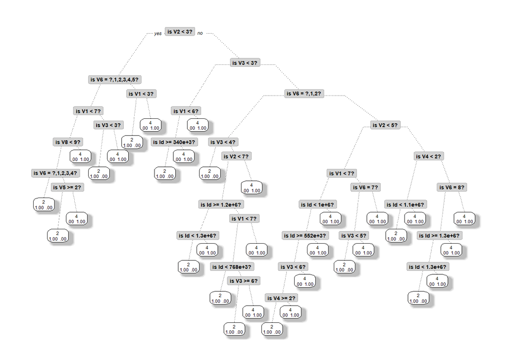

```r
prp(brCanTree,extra=4, # display prob of classes in the node
    branch=.5, # change angle of branch lines
    shadow.col="gray", # shadows under the leaves
    branch.lty=3, # draw branches using dotted lines
    split.cex=1.2, # make the split text larger than the node text
    split.prefix="is ", # put "is " before split text
    split.suffix="?", # put "?" after split text
    split.box.col="lightgray", # lightgray split boxes (default is white)
    split.border.col="darkgray", # darkgray border on split boxes
    split.round=.5)
```

```r
(best.CP = brCanTree$cptable[which.min(brCanTree$cptable[,"xerror"]),"CP"])
```

```
## [1] 0.004149378
```

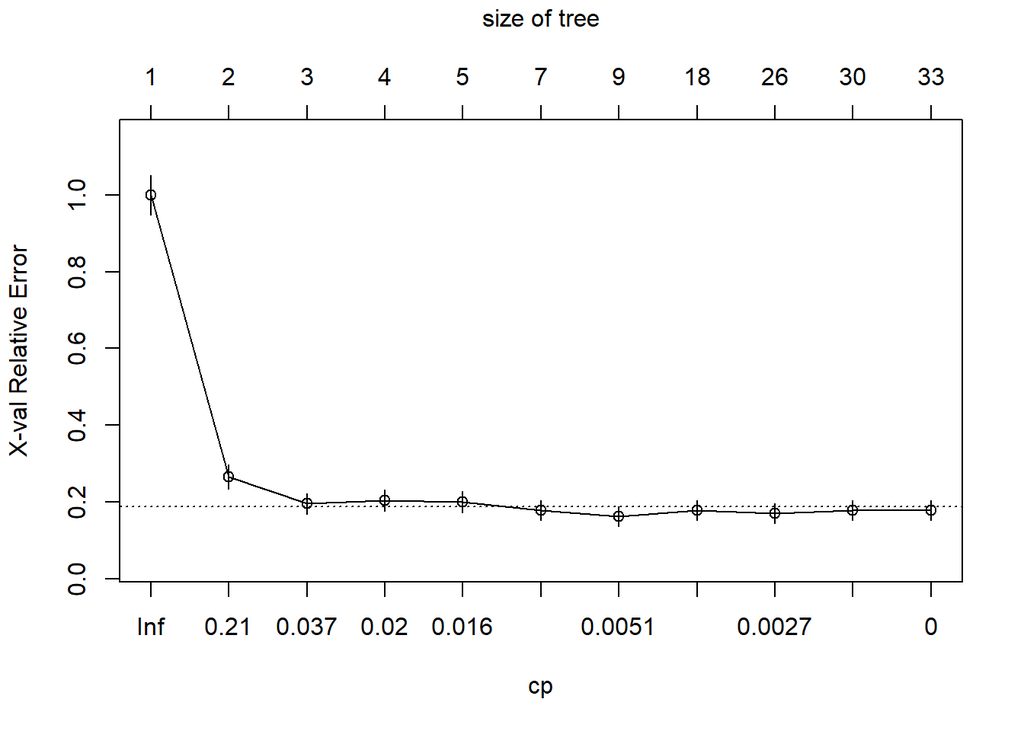

```r
plotcp(brCanTree)
```

Prune the tree more than suggested by `best.CP` value 0.0041494 to make analysis easier.

```r
prunedTree <- prune(brCanTree, cp = 0.0062241)
printcp(prunedTree)
```

```
##
## Classification tree:
## rpart(formula = Class ~ ., data = datBreastCancer, method = "class",
##     control = rpart.control(cp = 0, minbucket = 1, minsplit = 2))
##
## Variables actually used in tree construction:
## [1] V1 V2 V3 V6
##
## Root node error: 241/699 = 0.34478
##
## n= 699
##
##          CP nsplit rel error  xerror     xstd
## 1 0.7800830      0  1.000000 1.00000 0.052142
## 2 0.0539419      1  0.219917 0.26556 0.031639
## 3 0.0248963      2  0.165975 0.19502 0.027474
## 4 0.0165975      3  0.141079 0.20332 0.028009
## 5 0.0145228      4  0.124481 0.19917 0.027743
## 6 0.0062241      6  0.095436 0.17842 0.026359
```

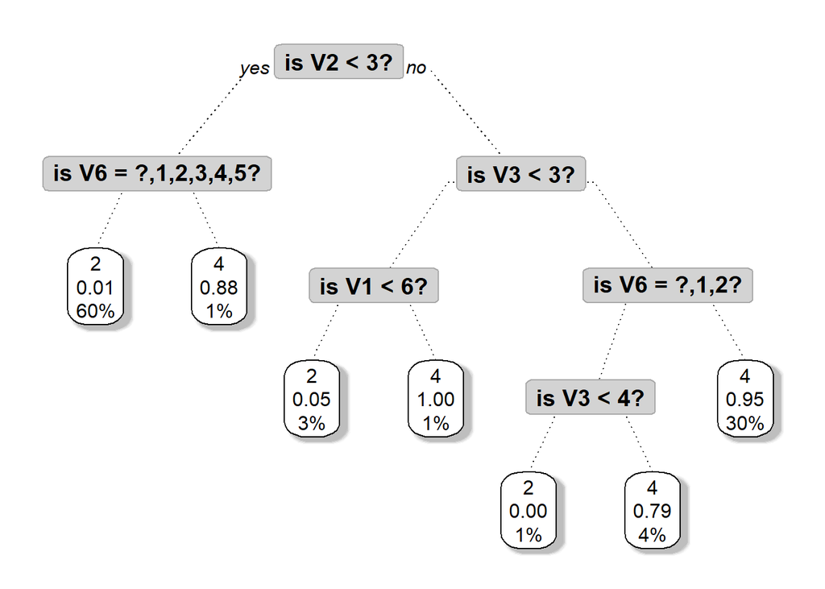

```r
prp(prunedTree,extra=106, # display prob of classes in the node
    branch=.5, # change angle of branch lines
    shadow.col="gray", # shadows under the leaves
    branch.lty=3, # draw branches using dotted lines
    split.cex=1.2, # make the split text larger than the node text
    split.prefix="is ", # put "is " before split text
    split.suffix="?", # put "?" after split text
    split.box.col="lightgray", # lightgray split boxes (default is white)
    split.border.col="darkgray", # darkgray border on split boxes
    split.round=.5)
```

1. Observe the tree.
2. Define event $E_1$ as `E1={(V2>=2.5),(V3>=2.5),V6!=<?,1,2>}`. Calculate probability $P(E_1)$
3. Calculate probability $P(4|E_1)$
4. Define event $E(V6=2)$ as all combinations of events (paths on the tree) including event $V6=2$. Calculate probability $P(4|E(V6=2))$
5. Define event $E(V3=3)$ as all combinations of events (paths on the tree) satisfying $V3=3$. Calculate probability $P(4|E(V3=3))$
6. Calculate probability $P(E_1|4)$ using Bayes Theorem and directly from the observed data